# Intro to ggplot

Andrew Bell

2022

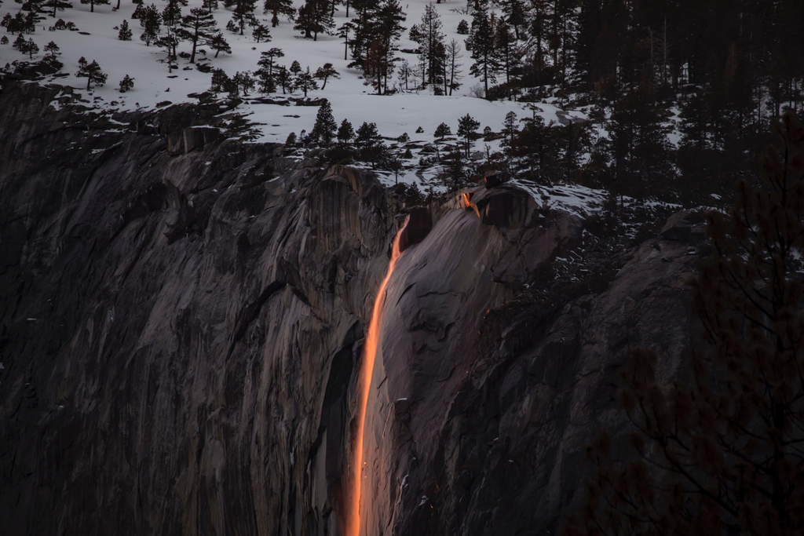

## Learning Objectives

- Review Rzero
- Learn the grammar of graphics
- Understand ggplot syntax
- Start adding to your data visualization toolset

## Review RZero

In essence, most everything you do in R involves **objects**. **Functions** take **arguments** (some of which are objects) and produce outputs (which you can assign to a new object).

Data frames are made up of multiple lists. You can create dataframes using the data_frame() function.

```r
#new object "my_kids" assigned the output of the function "c". The function c creates a list of strings(my_family) or numbers(kid_ages)

my_family <- c("Katie","Finn","Jack","Josie")
kid_ages <- c(NA,2,4,6)
df <- tibble(my_family, kid_ages)

df
```

```
## # A tibble: 4 × 2
##   my_family kid_ages
##   <chr>        <dbl>
## 1 Katie           NA
## 2 Finn             2
## 3 Jack             4
## 4 Josie            6
```

- **Operators** - can manipulate **objects** (this manipulation can be assigned to a **new object**). To reference specific columns within a dataframe use the `$` symbol (i.e. dataframe`$`columnname).

```r
#new object "how_old_my_kids_will_be_in_5_years" is assigned to the output of kids_ages plus 5

how_old_my_kids_will_be_in_5_years <- df$kid_ages + 5

how_old_my_kids_will_be_in_5_years
```

```
## [1] NA  7  9 11
```

- **Functions** - accept **objects** and returns the result of the function (which can be assigned to a **new object**). NA values can be the bane of any R coder’s existence. Try running the code below without the argument na.rm = TRUE, what does the function return? What do you think na.rm does?

```r
#new object "average_age" is assigned to the output the function mean() which is accepting the kid_ages object

average_age <- mean(kid_ages, na.rm = TRUE)

average_age
```

```
## [1] 4
```

At this point, if you don’t feel comfortable with the differences between objects, functions, arguments, and operators go back to Rzero and work through that lesson again.

## The Grammar of Graphics

What is the grammar of linguistics?

The grammar is the set of structural rules governing the composition of clauses, phrases, and words in a natural language. So what is the grammar of graphics - what are rules by which we can construct a graphic?

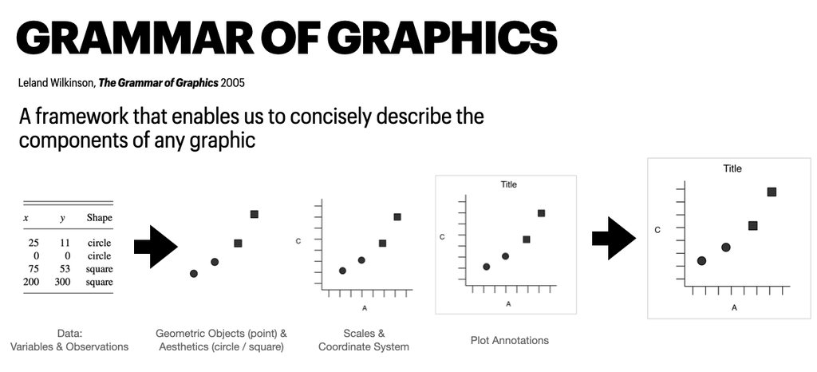

The essential building blocks of a graphic:

- Data
- Aesthetics
- Geometric Objects
- Scales
- Coordinate System
- Statistical Transformations

With the building blocks and rules developed by Wilkinson in 2005, we can construct pretty much any visualization we want.

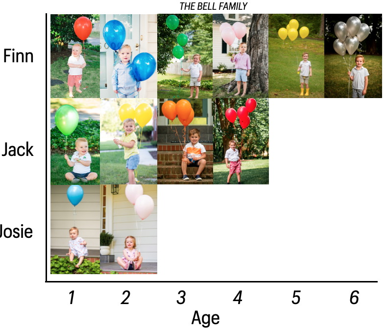

ggplot() is a function built into the tidyverse package that uses the grammar of graphics framework to construct visualizations.

## Learning ggplot syntax

We want to be able to make visualizations from data - so we need a function that outputs a plot based on the objects and arguments we give it. Enter the **ggplot()** function. Below is most basic syntax (structure of code required to make the function work) of the ggplot function.

`ggplot(data = <DATA>) + <GEOM_FUNCTION>(mapping = aes(<MAPPINGS>))`

We are going to use the friends_info dataset we used at the end of Rzero to get started with ggplot().

First let’s take a look at our friends_info. Note how many variables and observations are found in the dataset.

```r
friends_info <- read_csv("data/friends_info.csv")
friends_info

head(friends_info)
```

[output not shown]

We want to create an object (first_viz) that contains a visualization created by the ggplot function. The ggplot function takes two essential arguments: data and the mapping of variables to specific aesthetics (like x and y coordinates). For our first visualization, we are going to plot the number of view (US_views_millions) by the critic ratings (imdb_rating) for each episode.

```r
first_viz <- ggplot(data = friends_info,
                    mapping = aes(x = us_views_millions,
                                  y = imdb_rating))
```

Our object now needs a geom layer (think plot type, e.g. scatterplot or bar plot) so we’ll add that layer to our existing first_viz object. Note: in order to show the plot in the code chunk, we need to call the object that contains it (first_viz).

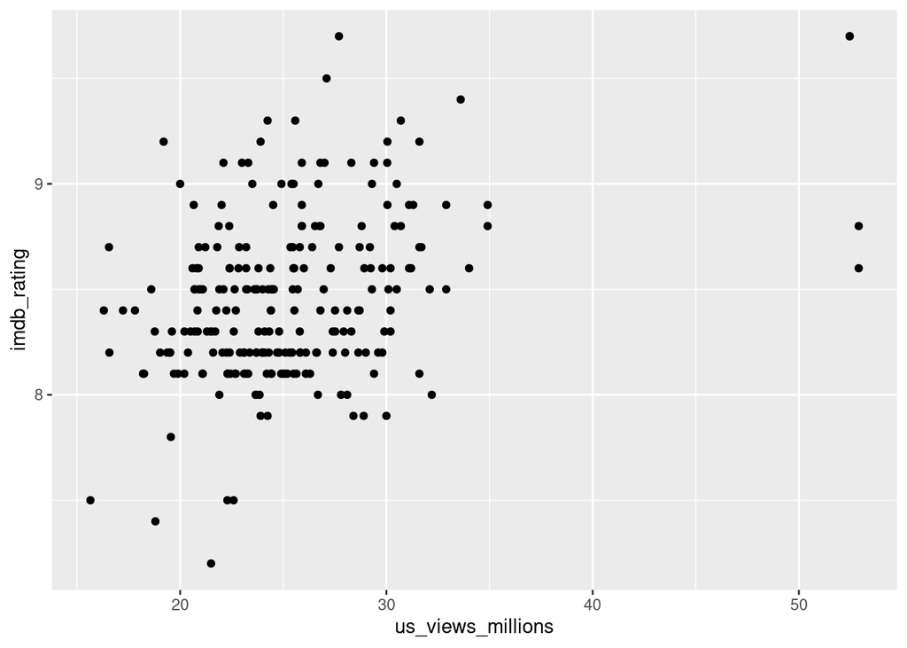

```r
first_viz <- first_viz + geom_point()

first_viz
```

We can continue to add layers to our visualization to do things like format the axis labels, change the axis scales, annotate specific elements of the plot area, etc.

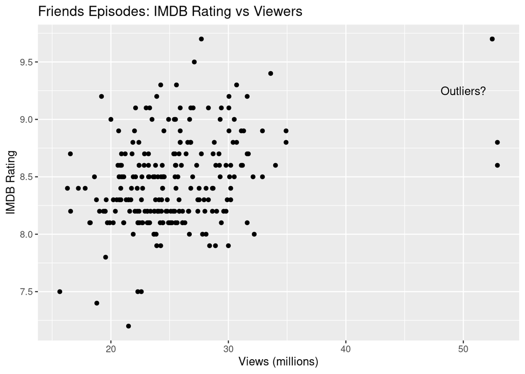

```r
first_viz <- first_viz +
  labs(title = "Friends Episodes: IMDB Rating vs Viewers",
       x = "Views (millions)",
       y = "IMDB Rating")+
  scale_y_continuous(breaks = seq(7,10.5, by = 0.5))+
  annotate("text", x = 50, y = 9.25, label = "Outliers?")

first_viz
```

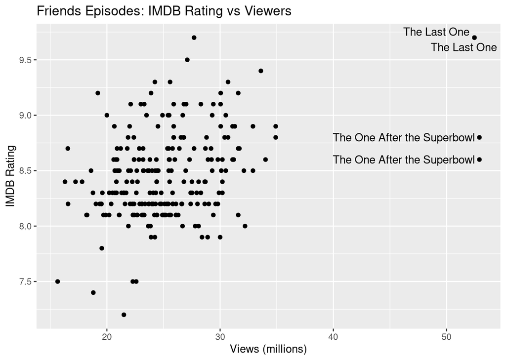

```r
first_viz <-  ggplot(data = friends_info,
                    mapping = aes(x = us_views_millions, y = imdb_rating))+
  geom_point()+
  geom_text_repel(data = subset(friends_info, us_views_millions > 40),
                                         mapping = aes(label = title))+
  labs(title = "Friends Episodes: IMDB Rating vs Viewers",
       x = "Views (millions)",
       y = "IMDB Rating")+
  scale_y_continuous(breaks = seq(7,10.5, by = 0.5))

first_viz
```

## Exercise: Creating a visualization

I want you to now create your own visualization that explores the how the shows popularity changed over time.

Instructions:

- 1 Create a new object that contains your visualization (use the friends_info dataset)
- 2 Use a geom to create a scatterplot that maps time to the x axis and USA views to the y axis
- 3 Make sure your visualization has a proper title and axis labels

```r
#your code here
```

## Learning all of ggplot’s layers

This simply takes lots of practice. The discoverability of these layers requires knowledge of the options. One the major downsides to R but there are many resources to help.

Resources to help:

- [ggplot cheatsheat](https://github.com/rstudio/cheatsheets/raw/master/data-visualization-2.1.pdf)
- [Esquisser](https://dreamrs.github.io/esquisse/) package as a GUI introduction to the ggplot syntax.

**Esquisse** This is a great tool to get students comfortable with ggplot’s layer / syntax.

```r
#esquisser()
```